# Random Forest + Boosted Linear Ensemble Forecasting

2020-01-16

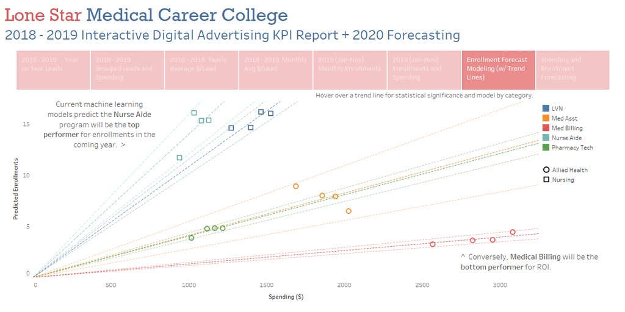

*Student enrollment forecasting graphic*

> **Can we forecast medical student enrollments using advertising data from web-based platforms?**

This is the question I tried to answer using Lone Star Medical Career College’s digital advertising campaign, spending, and student enrollment data to forecast enrollments for the coming year. You see, over Christmas break I started brainstorming how to use my recent machine learning training to provide a useful solution to a real world business problem. As I started to develop [KPI charts for Lone Star Medical Career College](https://public.tableau.com/profile/george.garcia3963#!/vizhome/LoneStarMedicalCareerCollege/LoneStarMedicalCareerCollege), it became apparent to me that this might be my big opportunity to apply the predictive modeling workflow I had just learned in my ML class. The following notebook highlights my first attempt at this real world problem.

*Note:* Although each digitial advertising campaign generates hourly data, this was my first attempt at developing forecasting models (or really any kind of real world data model) and so I decided to go with the data supplied on their KPI spreadsheet. Future development will be a big data project with actual hourly social media advertising data. Also, the name of the college was changed to ensure company privacy.

```r
# Libraries
library(caret)
library(skimr)
library(corrplot)
```

# The Data

## Imported Data

The predicted variable here is student enrollments. Why student enrollments? For a career college, this is the main return on investment (ROI) figure. Technically, the return for all the time and resources that go into digital marketing can be measured in many different ways: demographic exposure, increases in online followers, etc. In this case, I wanted any work I do to potentially have a direct impact on the company’s bottom line. This is a common tactic, [the researchers on Garter.com tell me](https://www.gartner.com/en), for any company piloting a data mining initiative.

At first, I incorporated other marketing-based dependent variables into the data such as lead counts and social media platform (Google Ads vs. Facebook Ads), but initial model performances seemed rather low. After some refinement and visual exploration using *Tableau*, I settled for the following dependent variables: campaign type and spending.

```r
# Import and clean data
data <- read.csv("C:/Users/george/Documents/Digital Marketing Data/Triggers/spendingAndEnrollments.csv")
dataRGV <- data
dataRGV
```

| Campaign | Spending | Enrollments |
| --- | --- | --- |
| LVN | 1267.90 | 13 |
| Med Billing | 1770.33 | 3 |
| Pharmacy | 974.73 | 3 |
| Nurse Aide | 992.85 | 9 |
| Med Asst | 1941.95 | 8 |
| LVN | 1286.50 | 11 |
| Med Billing | 2157.41 | 1 |
| Pharmacy | 940.48 | 0 |
| Nurse Aide | 849.21 | 9 |
| Med Asst | 1965.67 | 2 |

[output cut: 41 more lines]

## Skimmed Data

A quick *skim_to_wide()* using *skimr* allows an at-a-glance view of the imported data. Campaign is a factor variable and spending is numeric. Before visualizing or processing the campaign variable, I will have to convert it to to a numeric dummy variable for better performance. I also note that there are only 51 instances of this data, so how I decide to partition the data will have a bigger impact on performance than usual.

```r
# Split data
x <- subset(dataRGV, select = -Enrollments)
y <- subset(dataRGV, select = Enrollments)

# Data summary
skimX <- skim_to_wide(x)
skimY <- skim_to_wide(y)
skimX
```

| type | variable | missing | complete | n | n_unique | top_counts | ordered | mean | sd | p0 | p25 | p50 | p75 | p100 | hist |
| --- | --- | --- | --- | --- | --- | --- | --- | --- | --- | --- | --- | --- | --- | --- | --- |
| factor | Campaign | 0 | 51 | 51 | 5 | LVN: 11, Med: 11, Nur: 11, Pha: 11 | FALSE | NA | NA | NA | NA | NA | NA | NA | NA |
| numeric | Spending | 0 | 51 | 51 | NA | NA | NA | 1377.28 | 505.05 | 361.74 | 957.61 | 1232.31 | 1777.63 | 2270.39 |  |

```r
skimY
```

| type | variable | missing | complete | n | mean | sd | p0 | p25 | p50 | p75 | p100 | hist |
| --- | --- | --- | --- | --- | --- | --- | --- | --- | --- | --- | --- | --- |
| integer | Enrollments | 0 | 51 | 51 | 9.2 | 8.03 | 0 | 3 | 8 | 13 | 31 |  |

```r
# Data partition
seed <- 123
set.seed(seed)
dataPart <- createDataPartition(y$Enrollments,
                              p = .70,
                              list = FALSE)
xTrain <- x[dataPart,]
yTrain <- y[dataPart,]

xTest <- x[-dataPart,]
yTest <- y[-dataPart,]
```

## Training Data Visualization and Correlation

For a visual component to the training data, I use the standard boxplot and histogram charts. I also plot the correlation between variables. At this point I note that no correlation screening seems necessary for this data, and the only outliers are in the dependent variable data.

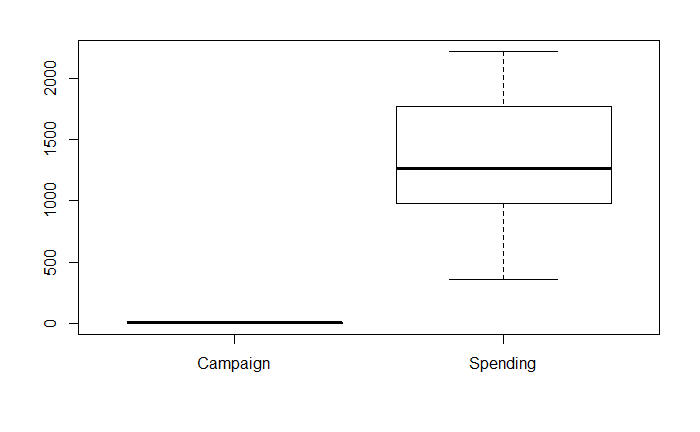

```r
# Create numeric set of x variables
xTrainNum <- as.data.frame(sapply(xTrain, as.numeric))

# Boxplot of predictors
boxplot(xTrainNum)
```

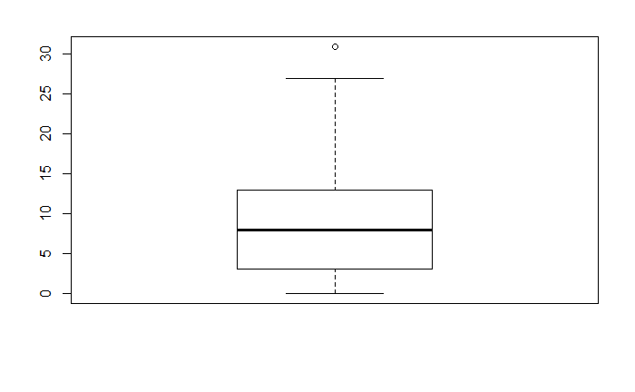

```r
boxplot(yTrain)
```

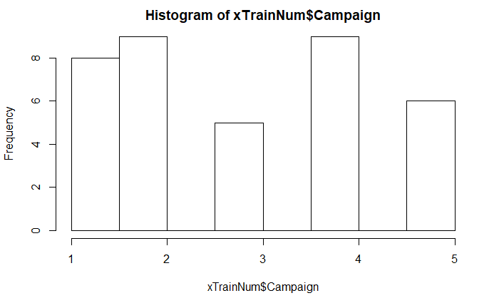

```r
# Histograms
hist(xTrainNum$Campaign)
```

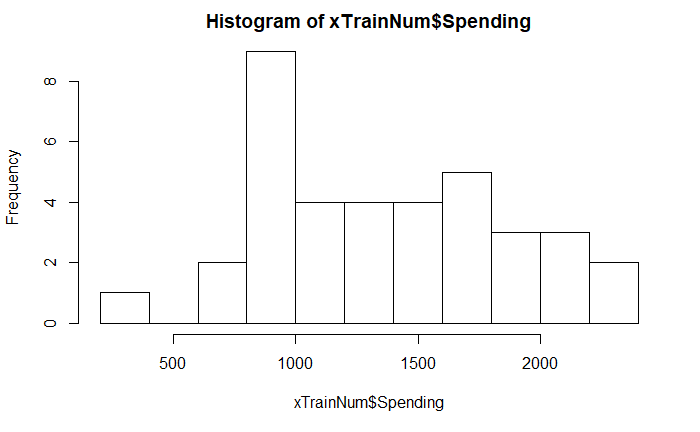

```r
hist(xTrainNum$Spending)
```

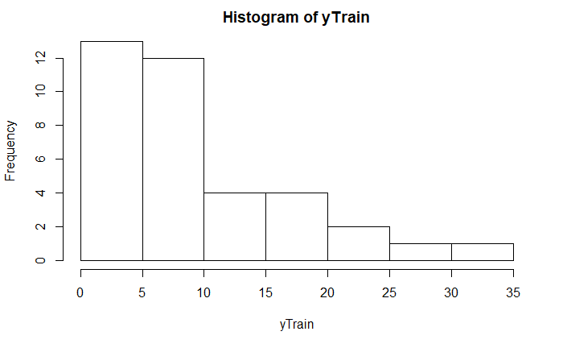

```r
#hist(as.numeric(yTrain))
hist(yTrain)
```

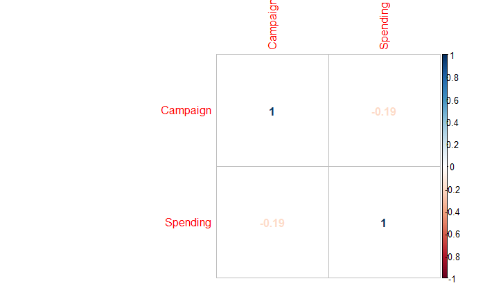

```r
# Correlation plots and correlation ceiling
correlations <- cor(xTrainNum)
corrplot(correlations, method = "number", order = "hclust")
```

# ML Algorithm Training

## Pre-processing

I preprocessed using the standard *center/scaling* and *YeoJohnson* to normalize the data, and *spatialSign* for outliers (which I don’t think is necessary, but I usually add it anyway as it might boost performance a bit). I also used 10-fold repeated cross validation for resampling. In addition, I used dummy variables to account for the Campaign factor variable, and tuned all models.

## Models and Tuned Performance

Using the *caret* workflow, I trained the data on the following models:

- Boosted Linear Regression *(BstLm)*
- Elastic Net Regression *(enet)*
- Generalized Linear Regression *(glmnet)*
- Least Angle Regression *(lars)*
- Random Forest *(rf)*

# Finalized Model Performance on Test Data

## Train and Evaluate ‘rf’ + ‘BstLm’ Model Ensemble

Since overall performance is comparable, I’ll go ahead and roll with it for the enrollment forecasting.

# Final Model Prediction: Forecasted Enrollments

- Dec + 10%
- Dec + 15%
- Dec + 20%

## Project Limitations

Since this is the first kind of applied data mining project for both the medical school and their digital marketing company, the transaction channel between company ad spending and student enrollment counts is not yet automated into a database, and it is not clear how either company communicates this type of ROI with each other. In other words, we can not fully account for the amount of student enrollments that are solely attributed to ad-generated leads and spending. Unfortunately, this is a major issue when attempting to forecast future enrollments. Due to this fact, the model developed appears to be overfit and does not handle new data as well as hoped.

Future developments may include more grainular, hourly data sourced from the online platforms themselves and perhaps developing a less overfit model. In addition, maybe a new strategy for seeing ad-generated leads through to enrollments can be optimized for much better marketing funnel business intelligence performance.

In any case, I learned a lot about both the digital advertising space and the importance of streamlining business processes for optimized intelligence.